# Texas Skewed Dist 2

Xianbin Cheng

May 7, 2018

## Method

1. Load the libraries and read in files.

```r
library(tidyverse)
library(kableExtra)
```

```r
weight = read.csv("TX weight.csv", header = TRUE, stringsAsFactors = FALSE)
bulk = read.csv("Bulk Level.csv", header = TRUE, stringsAsFactors = FALSE)
```

```r
str(weight)
```

```
## 'data.frame':    528 obs. of  4 variables:
##  $ Kernel_ID  : chr  "101-1" "101-10" "101-11" "101-12" ...
##  $ AF.ppb.    : num  0.0181 0.6648 0.6648 0.6648 0.6648 ...
##  $ FM.ppm.    : num  0.00241 0.00241 0.00241 0.00241 0.00241 ...
##  $ m.kernel..g: num  0.404 0.214 0.374 0.244 0.334 ...
```

| Class | Bulk_Aflatoxin.ppb. | Bulk_Fumonisin.ppm. |
| --- | --- | --- |
| LL | 0.0 | 0.0 |
| LM | 4.2 | 2.7 |
| LH | 0.4 | 8.0 |
| ML | 20.0 | 0.7 |
| MM | 37.0 | 2.1 |
| MH | 33.0 | 5.4 |
| HL | 65.0 | 0.1 |
| HM | 63.0 | 3.0 |
| HH | 158.0 | 8.0 |

2. Pre-process the dataset by adding two variables: `Plate_ID` and `Kernel`. `Plate_ID` is the first three digits in the `Kernel_ID` and `Kernel` is the individual kernel identifier. Also, add the class labels `AF_class` and `FM_class`.

```r
## Aflatoxin class
AF_class = ifelse(weight$AF.ppb. < 20, "L", "M")
AF_class[weight$AF.ppb. >= 50] = "H"
AF_class[is.na(weight$AF.ppb.)] = "L"
AF_class = factor(AF_class, levels = c("H", "M", "L"))
summary(AF_class)
```

```
##   H   M   L
##   6   0 522
```

```r
## Fumonisin class
FM_class = ifelse(weight$FM.ppm. < 1, "L", "M")
FM_class[weight$FM.ppm. >= 4] = "H"
FM_class[is.na(weight$FM.ppm.)] = "L"
FM_class = factor(FM_class, levels = c("H", "M", "L"))
summary(FM_class)
```

```
##   H   M   L
##  35   7 486
```

```r
## Combine by columns
weight2 = weight %>%
  mutate(Plate_ID = substr(Kernel_ID, start = 1, stop = 3),
         Kernel = substr(Kernel_ID, start = 5, stop = 6),
         AF_class = AF_class,
         FM_class = FM_class)
```

```r
str(weight2)
```

```
## 'data.frame':    528 obs. of  8 variables:
##  $ Kernel_ID  : chr  "101-1" "101-10" "101-11" "101-12" ...
##  $ AF.ppb.    : num  0.0181 0.6648 0.6648 0.6648 0.6648 ...
##  $ FM.ppm.    : num  0.00241 0.00241 0.00241 0.00241 0.00241 ...
##  $ m.kernel..g: num  0.404 0.214 0.374 0.244 0.334 ...
##  $ Plate_ID   : chr  "101" "101" "101" "101" ...
##  $ Kernel     : chr  "1" "10" "11" "12" ...
##  $ AF_class   : Factor w/ 3 levels "H","M","L": 3 3 3 3 3 3 3 3 3 3 ...
##  $ FM_class   : Factor w/ 3 levels "H","M","L": 3 3 3 3 3 3 3 3 3 3 ...
```

3. Calculate the weight fraction of each kernel within each bulk group and call it `wt_frac`. `wt_frac`$ = m_i / m_{total}$.

```r
## Create a function that calculates the weight fraction.
wt_frac_func = function(df){
  df = df %>%
    mutate(wt_frac = m.kernel..g / sum(m.kernel..g))
}

## Split weight2 based on Plate_ID, apply wt_frac_func() to each subset, and combine the results by rows.
weight3 = weight2 %>%
  split(x = ., f = weight2$Plate_ID) %>%
  lapply(X = ., FUN = wt_frac_func) %>%
  do.call(what = rbind.data.frame, args = .)
```

```r
str(weight3)
```

```
## 'data.frame':    528 obs. of  9 variables:
##  $ Kernel_ID  : chr  "101-1" "101-10" "101-11" "101-12" ...
##  $ AF.ppb.    : num  0.0181 0.6648 0.6648 0.6648 0.6648 ...
##  $ FM.ppm.    : num  0.00241 0.00241 0.00241 0.00241 0.00241 ...
##  $ m.kernel..g: num  0.404 0.214 0.374 0.244 0.334 ...
##  $ Plate_ID   : chr  "101" "101" "101" "101" ...
##  $ Kernel     : chr  "1" "10" "11" "12" ...
##  $ AF_class   : Factor w/ 3 levels "H","M","L": 3 3 3 3 3 3 3 3 3 3 ...
##  $ FM_class   : Factor w/ 3 levels "H","M","L": 3 3 3 3 3 3 3 3 3 3 ...
##  $ wt_frac    : num  0.0278 0.0147 0.0257 0.0168 0.023 ...
```

4. Calculate the weighted aflatoxin and fumonisin concentration for each kernel. `wt_af` = `AF.ppb` x `wt_frac`. `wt_fm` = `FM.ppm.` x `wt_frac`.

```r
weight4 = weight3 %>%
  mutate(wt_af = AF.ppb. * wt_frac,
         wt_fm = FM.ppm. * wt_frac)

weight4$Kernel = as.numeric(weight4$Kernel)
```

```r
str(weight4)
```

```
## 'data.frame':    528 obs. of  11 variables:
##  $ Kernel_ID  : chr  "101-1" "101-10" "101-11" "101-12" ...
##  $ AF.ppb.    : num  0.0181 0.6648 0.6648 0.6648 0.6648 ...
##  $ FM.ppm.    : num  0.00241 0.00241 0.00241 0.00241 0.00241 ...
##  $ m.kernel..g: num  0.404 0.214 0.374 0.244 0.334 ...
##  $ Plate_ID   : chr  "101" "101" "101" "101" ...
##  $ Kernel     : num  1 10 11 12 13 14 15 16 17 18 ...
##  $ AF_class   : Factor w/ 3 levels "H","M","L": 3 3 3 3 3 3 3 3 3 3 ...
##  $ FM_class   : Factor w/ 3 levels "H","M","L": 3 3 3 3 3 3 3 3 3 3 ...
##  $ wt_frac    : num  0.0278 0.0147 0.0257 0.0168 0.023 ...
##  $ wt_af      : num  0.000504 0.009783 0.017105 0.011156 0.015274 ...
##  $ wt_fm      : num  6.69e-05 3.54e-05 6.20e-05 4.04e-05 5.53e-05 ...
```

5. Sort the dataset on `Plate_ID` and `Kernel`.

```r
weight5 = weight4 %>%
  arrange(.data = ., Plate_ID, Kernel)
```

```r
str(weight5)
```

```
## 'data.frame':    528 obs. of  11 variables:
##  $ Kernel_ID  : chr  "101-1" "101-2" "101-3" "101-4" ...
##  $ AF.ppb.    : num  0.0181 0.0181 0.0181 0.0181 0.0181 ...
##  $ FM.ppm.    : num  0.00241 0.00241 0.00241 0.00241 0.00241 ...
##  $ m.kernel..g: num  0.404 0.254 0.354 0.204 0.264 ...
##  $ Plate_ID   : chr  "101" "101" "101" "101" ...
##  $ Kernel     : num  1 2 3 4 5 6 7 8 9 10 ...
##  $ AF_class   : Factor w/ 3 levels "H","M","L": 3 3 3 3 3 3 3 3 3 3 ...
##  $ FM_class   : Factor w/ 3 levels "H","M","L": 3 3 3 3 3 3 3 3 3 3 ...
##  $ wt_frac    : num  0.0278 0.0175 0.0244 0.014 0.0182 ...
##  $ wt_af      : num  0.000504 0.000317 0.000442 0.000254 0.000329 ...
##  $ wt_fm      : num  6.69e-05 4.21e-05 5.86e-05 3.38e-05 4.37e-05 ...
```

6. Split `weight5` on the bulk class (LL = 1, LM = 2, LH = 3, ML = 4, MM = 5, MH = 6, HL = 7, HM = 8, HH = 9).

```r
## Add a numeric column to the dataset "bulk" to identify bulk class.
bulk$Bulk_class = 1:9 %>% as.character()

## Join the two datasets and split on "Bulk_class".
bulk_group = weight5 %>%
  mutate(Bulk_class = substr(Plate_ID, start = 1, stop = 1)) %>%
  left_join(x = ., y = bulk, by = "Bulk_class") %>%
  split(x = ., f = .$Bulk_class)
```

```r
str(bulk_group[[1]])
```

```
## 'data.frame':    96 obs. of  15 variables:
##  $ Kernel_ID          : chr  "101-1" "101-2" "101-3" "101-4" ...
##  $ AF.ppb.            : num  0.0181 0.0181 0.0181 0.0181 0.0181 ...
##  $ FM.ppm.            : num  0.00241 0.00241 0.00241 0.00241 0.00241 ...
##  $ m.kernel..g        : num  0.404 0.254 0.354 0.204 0.264 ...
##  $ Plate_ID           : chr  "101" "101" "101" "101" ...
##  $ Kernel             : num  1 2 3 4 5 6 7 8 9 10 ...
##  $ AF_class           : Factor w/ 3 levels "H","M","L": 3 3 3 3 3 3 3 3 3 3 ...
##  $ FM_class           : Factor w/ 3 levels "H","M","L": 3 3 3 3 3 3 3 3 3 3 ...
##  $ wt_frac            : num  0.0278 0.0175 0.0244 0.014 0.0182 ...
##  $ wt_af              : num  0.000504 0.000317 0.000442 0.000254 0.000329 ...
##  $ wt_fm              : num  6.69e-05 4.21e-05 5.86e-05 3.38e-05 4.37e-05 ...
##  $ Bulk_class         : chr  "1" "1" "1" "1" ...
##  $ Class              : chr  "LL" "LL" "LL" "LL" ...
##  $ Bulk_Aflatoxin.ppb.: num  0 0 0 0 0 0 0 0 0 0 ...
##  $ Bulk_Fumonisin.ppm.: num  0 0 0 0 0 0 0 0 0 0 ...
```

7. Calculate the `wt_af`/`Bulk_Aflatoxin.ppb.` and `wt_fm`/`Bulk_Fumonisin.ppm.` for each bulk level.

```r
## Create a function for calculating percentages.
calc_perc = function(data){
  data %>%
    mutate(perc_af = wt_af / Bulk_Aflatoxin.ppb.,
           perc_fm = wt_fm / Bulk_Fumonisin.ppm.)
}

bulk_group_2 = lapply(X = bulk_group, FUN = calc_perc) %>%
  do.call(what = rbind.data.frame, args = .)
```

8. Visualize the weighted aflatoxin and fumonisin for each bulk class.

```r
## Create a function for visualization of weighted mycotoxin.
vis_af = function(df){
  df1 = df %>% arrange(.data = ., Class, desc(wt_af))
  ggplot(data = df1) +
    geom_bar(aes(x = 1:length(Kernel_ID), y = wt_af, fill = AF_class), stat = "identity") +
    facet_wrap(~ Class, scales = "free", labeller = label_both) +
    labs(y = "Weighted aflatoxin (ppb)", x = "Kernel") +
    scale_fill_discrete(name = "Individual AF Class") +
    theme_bw()
}

vis_fm = function(df){
  df1 = df %>% arrange(.data = ., Class, desc(wt_fm))
  ggplot(data = df1) +
    geom_bar(aes(x = 1:length(Kernel_ID), y = wt_fm, fill = FM_class), stat = "identity") +
    facet_wrap(~ Class, scales = "free", labeller = label_both) +
    labs(y = "Weighted fumonisin (ppm)", x = "Kernel") +
    scale_fill_discrete(name = "Individual FM Class") +
    theme_bw()
}
```

9. Visualize the percent mycotoxin contributed to the bulk for each bulk class.

```r
## Create a function for visualization of percentages of weighted mycotoxin.
vis_af_perc = function(df){
  df1 = df %>% arrange(.data = ., Class, desc(perc_af))
  ggplot(data = df1) +
    geom_bar(aes(x = 1:length(Kernel_ID), y = perc_af, fill = AF_class), stat = "identity") +
    facet_wrap(~ Class, scales = "free", labeller = label_both) +
    labs(y = "% Aflatoxin contributed to bulk", x = "Kernel") +
    scale_fill_discrete(name = "Individual AF Class") +
    scale_y_continuous(labels = scales::percent) +
    theme_bw()
}

vis_fm_perc = function(df){
  df1 = df %>% arrange(.data = ., Class, desc(perc_fm))
  ggplot(data = df1) +
    geom_bar(aes(x = 1:length(Kernel_ID), y = perc_fm, fill = FM_class), stat = "identity") +
    facet_wrap(~ Class, scales = "free", labeller = label_both) +
    labs(y = "% Fumonisin contributed to bulk", x = "Kernel") +
    scale_fill_discrete(name = "Individual FM Class") +
    scale_y_continuous(labels = scales::percent) +
    theme_bw()
}
```

## Results

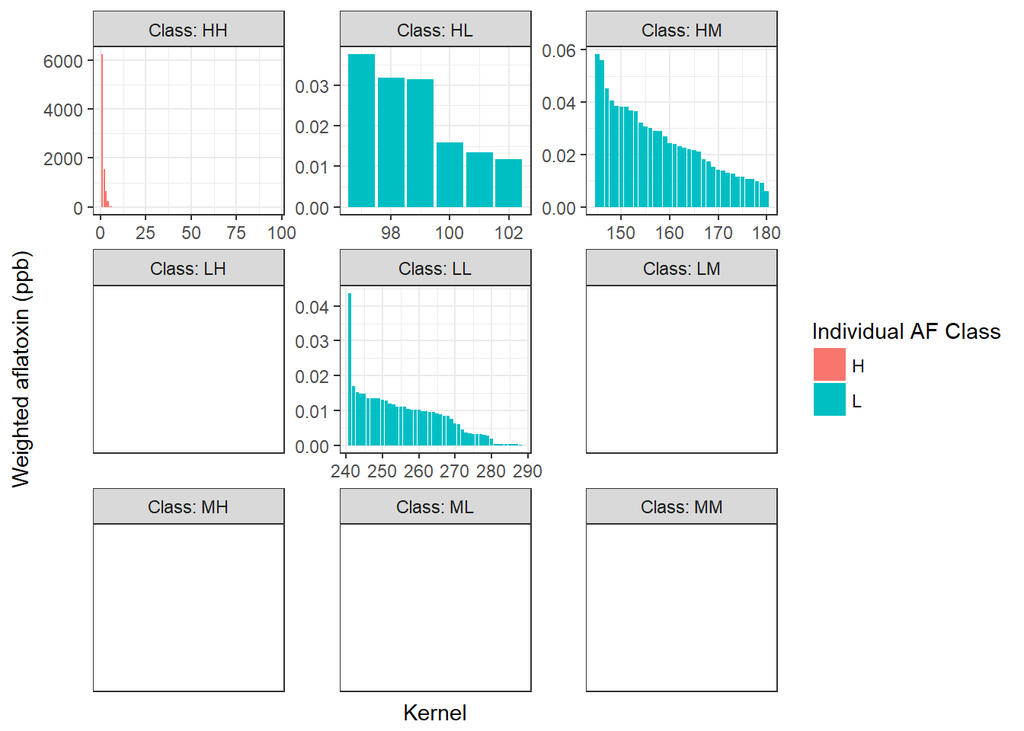

```r
## Weighted Aflatoxin
vis_af(bulk_group_2)
```

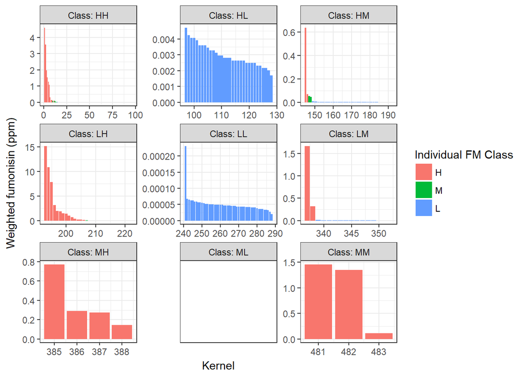

```r
## Weighted Fumonisin
vis_fm(bulk_group_2)
```

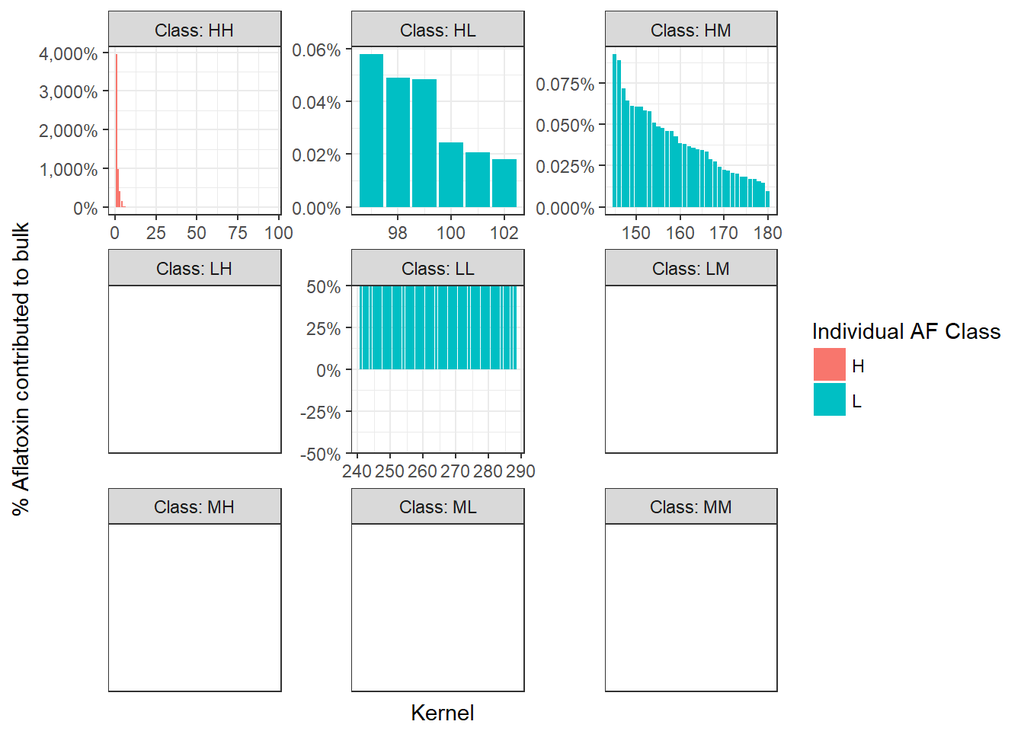

```r
## % Aflatoxin Contribution
vis_af_perc(bulk_group_2)
```

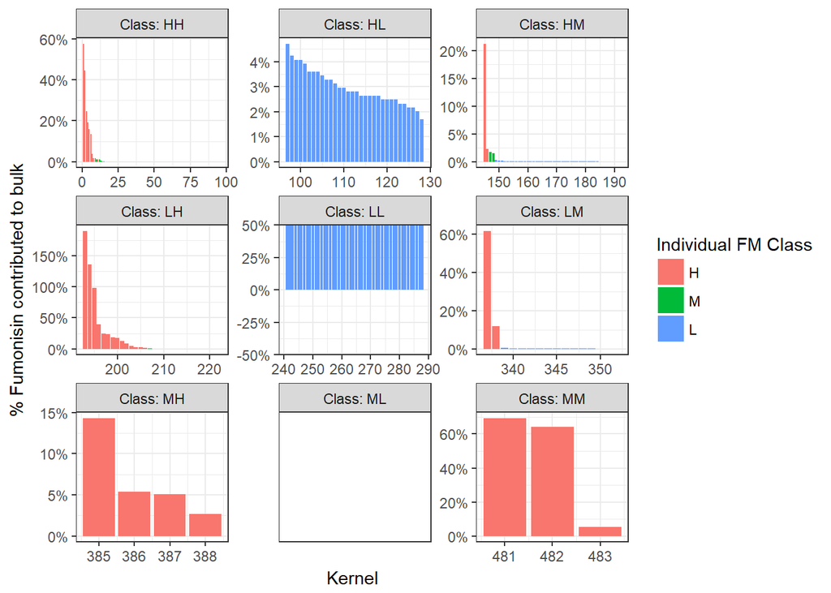

```r
## % Fumonisin Contribution
vis_fm_perc(bulk_group_2)
```